# R + StackOverflow Overview

August 20, 2019

- Programming Q/A site launched September 15, 2008 created by Jeff Atwood and Joel Spolsky
- Built as an open alternative to Q/A tech sites such as Experts Exchange
- Rigorous, engaged community with appointed and voted moderators
- Fosters a gaming style with points and milestone badges

## StackExchange Network

- Due to popularity became the flagship site in [SE network](https://stackexchange.com/sites#)

[figure not shown]

## Core of StackOverflow

- Users
  - **Askers**: Usually one-off, newcomers who ask few questions
  - **Answerers**: Usually long-term, advanced members
  - **Moderators**: Appointed and voted members to manage site
- Posts
  - Immediate help to original posters (OPs)
  - Future help to greater community
- Tags
  - Usually languages (C#, Java, Python, R)
  - Frameworks, tools, and modules (i.e., pandas, dplyr)

## R Tag

- [~11 year old tag](https://stackoverflow.com/tags/r/info) with over 300,000 questions to date
  - Creator: David Locke, CRUG Member
- [Top 20 tags](https://stackoverflow.com/tags?tab=popular) among software/web development stacks
- [Top R Users](https://stackoverflow.com/tags/r/info)
  - User: Dirk E., CRUG Member

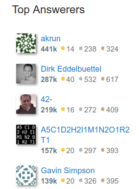

## Best Practices - Askers

- Research and debug enough (use SO as last resort)
- Make a genuine effort in trial and question
- Set up a [Minimum, Reproducible Example (MRE)](https://stackoverflow.com/help/minimal-reproducible-example)
  - Great resource: [How to make a great R reproducible example](https://stackoverflow.com/questions/5963269/how-to-make-a-great-r-reproducible-example)
  - Use `dput` or `data.frame` constructor

## Best Practices - Answerers

- Set up time to search for good attempts with reproducible examples
- Work through your comfortable skillsets:
  - `[r] [dataframe]`, `[r] [plot]`, `[r] [shiny]`
- Provide detailed explanation and in-line code comments
- Demonstrate code with data output and/or graph

## Quick Data Build

```r
### READ TABLE FORMATTED DATA
txt <- '   group int         num char  bool       date
1  stata  14 -0.01933983  FcC FALSE "1992-06-13"
2 python  15 -0.97016057  5V9  TRUE "1993-03-11"
3 python   8  0.01481491  llY FALSE "2017-01-28"
4    sas   5 -1.23408058  IXI FALSE "1985-09-03"
5      r  10  0.54730127  IIQ  TRUE "2015-12-16"
6      r   3 -1.16625133  05x  TRUE "1990-07-18"'

df <- read.table(text=txt, header=TRUE)
df
```

```
##    group int         num char  bool       date
## 1  stata  14 -0.01933983  FcC FALSE 1992-06-13
## 2 python  15 -0.97016057  5V9  TRUE 1993-03-11
## 3 python   8  0.01481491  llY FALSE 2017-01-28
## 4    sas   5 -1.23408058  IXI FALSE 1985-09-03
## 5      r  10  0.54730127  IIQ  TRUE 2015-12-16
## 6      r   3 -1.16625133  05x  TRUE 1990-07-18
```

## Data.Frame Example

```r
set.seed(8202019)
alpha <- c(LETTERS, letters, c(0:9))
data_tools <- c("sas", "stata", "spss", "python", "r", "julia")

random_df <- data.frame(
  group = factor(sample(data_tools, 500, replace=TRUE)),
  int = sample(1:15, 500, replace=TRUE),
  num = rnorm(500),
  char = replicate(500, paste(sample(alpha, 3, replace=TRUE), collapse="")),
  bool = sample(c(TRUE, FALSE), 500, replace=TRUE),
  date = as.Date(sample(1:as.integer(Sys.Date()), 500, replace=TRUE), origin="1970-01-01"),
  stringsAsFactors = FALSE
)
head(random_df)
```

```
##    group int        num char  bool       date
## 1  stata  14 -0.5096000  Bl8 FALSE 2019-05-11
## 2      r  11  0.4103947  EIf FALSE 1985-03-06
## 3 python  12 -1.9084805  6t9  TRUE 2015-01-19
## 4  julia   1 -0.5869093  hnu FALSE 2000-07-14
## 5   spss   5  0.3613189  XBY FALSE 1976-12-19
## 6      r   9  0.8342512  iay  TRUE 2014-06-08
```

## Dput Example

```r
### ASSIGN OBJECT TO RESULT OF dput(head(random_df))

reproduced_df <- structure(list(group = structure(c(6L, 2L, 2L, 4L, 3L, 3L), .Label = c("julia",
"python", "r", "sas", "spss", "stata"), class = "factor"), int = c(14L,
15L, 8L, 5L, 10L, 3L), num = c(-0.019339832897539, -0.970160572336964,
0.0148149050692396, -1.23408057869592, 0.547301270279682, -1.16625132915773
), char = c("FcC", "5V9", "llY", "IXI", "IIQ", "05x"), bool = c(FALSE,
TRUE, FALSE, FALSE, TRUE, TRUE), date = structure(c(8199, 8470,
17194, 5724, 16785, 7503), class = "Date")), row.names = c(NA,
6L), class = "data.frame")

reproduced_df
```

```
##    group int         num char  bool       date
## 1  stata  14 -0.01933983  FcC FALSE 1992-06-13
## 2 python  15 -0.97016057  5V9  TRUE 1993-03-11
## 3 python   8  0.01481491  llY FALSE 2017-01-28
## 4    sas   5 -1.23408058  IXI FALSE 1985-09-03
## 5      r  10  0.54730127  IIQ  TRUE 2015-12-16
## 6      r   3 -1.16625133  05x  TRUE 1990-07-18
```

## Challenges

- Askers
  - Not too invested with curated repository
  - Often do not care about craft or learning process
  - Passive group who comes and goes
- Answerers
  - Some over-help for rep points without best practices
  - Some over-suggest packages/aglorithms (e.g., tidyverse)
  - Some pose as bullies and intimidate newcomers
    - Updated Code of Conduct: https://stackoverflow.com/conduct

## StackOverflow API Data Analytics Workshop

[figure not shown]

- Break up into ~5 person(s) group
- Launch R notebooks (RStudio or Jupyter) on a computer
- Answer guided questions along Posts, Users, and Tags or find other insights
- Alternate someone to type table/plot solutions
- Submit notebook (PR or email) for presentation